# Informe Primer Semestre 2021

Fe y Ética

Claudio Rojas. Director Académico

2021-07-31

## 0.1 Presentación

El presente informe tiene como objetivo revisar el trabajo del sector, a través de información que sistematiza los resultados académicos del I semestre y recoge lo proyectado para el II semestre del presente año. Además, consideran las definiciones claves que tenemos como colegio pero también como institución de la Compañía de Jesús.

Los apartados del informe son:

- Definiciones Claves
- Informe de Notas
- Metas de Aprendizaje.
- Propuestas de Evaluación II Semestre.
- Sugerencias para la planificación de las unidades 2 y 3.

Cada una de las partes de informe incluye sugerencias que buscan orientar la reflexión y práctica del sector para poder realizar los ajustes que sean necesarios para el logro de los aprendzajes que sean definidos.

## 0.2 Definiciones Claves

Les recuerdo tener presente las definiciones claves tanto a nivel de red ignaciana como interna que deben siempre orientar nuestro trabajo académico.

### 0.2.1 Envío 3 Planificación Estratégica de los colegios Jesuitas

Asegurar que los 10 colegios y escuelas jesuitas desarrollen las prácticas y procesos necesarios para ofrecer la excelencia académica propia de una comprensión ignaciana de la educación de calidad.

### 0.2.2 Nuestra Definición de Calidad

Nosotros, como comunidad sanjavierina, entendemos por educación de calidad todo aprendizaje que nos lleva a descubrir y desarrollar nuestras capacidades de manera integral, formándonos como personas competentes, conscientes, comprometidas, compasivas y creativas, para así conocer y amar más y mejor a Jesucristo, sirviendo a nuestros hermanos en los diversos contextos sociales.

### 0.2.3 Nuestro Foco de Mejora

Fortalecer la propuesta curricular, con una didáctica renovada, bajo el Paradigma Pedagógico Ignaciano.

## 0.3 Informe de Notas

En el caso de los resultados, les sugiero analizar:

- Los promedios finales obtenidos por cada nivel
- Cantidad de estudiantes que están en cada nivel de logro.
- Las diferencias de resultados entre hombres y mujeres.

### 0.3.1 Tabla Resumen de Notas:

Esta tabla incluye la información de la asignatura por nivel en cuanto:

- Promedio de la asignatura.
- Nota Mínima.
- Mediana.
- Nota Máxima.

[output not shown]

### 0.3.2 Notas de 1º básico a IIº medio

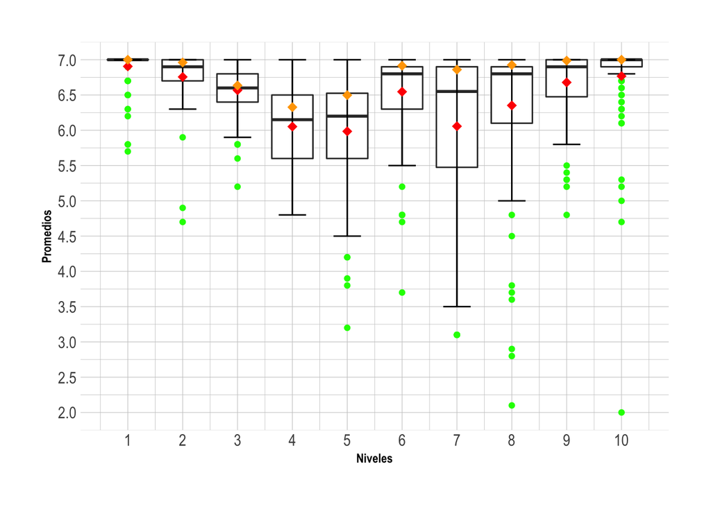

### 0.3.3 Distribución de Estudiantes por Niveles de Logro y diferenciado por Sexo.

#### 0.3.3.1 Primeros Básicos

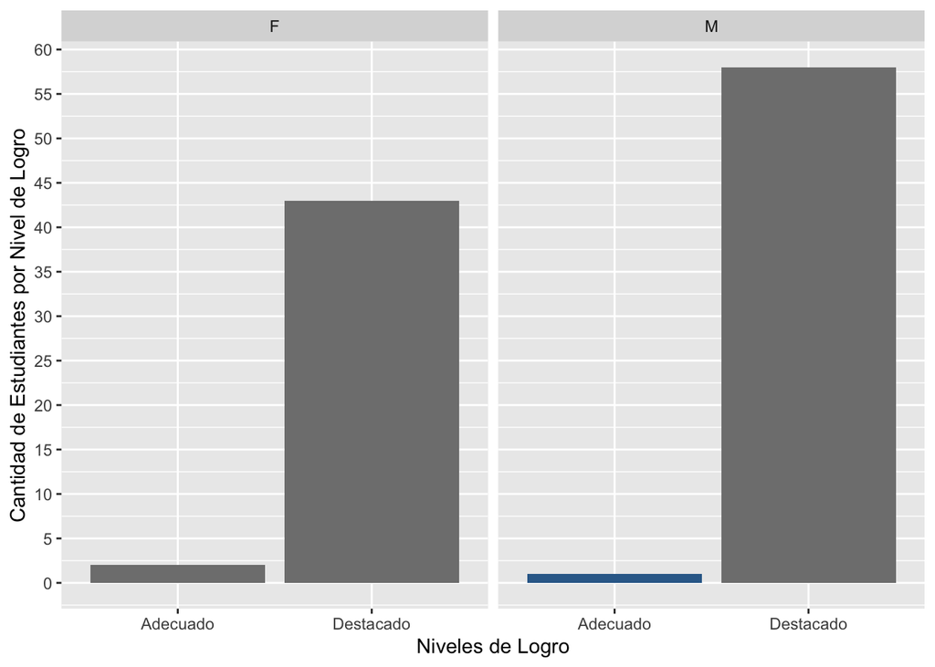

### Segundos Básicos

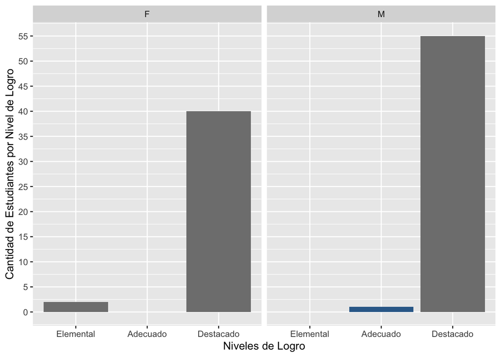

#### 0.3.3.2 Terceros Básicos

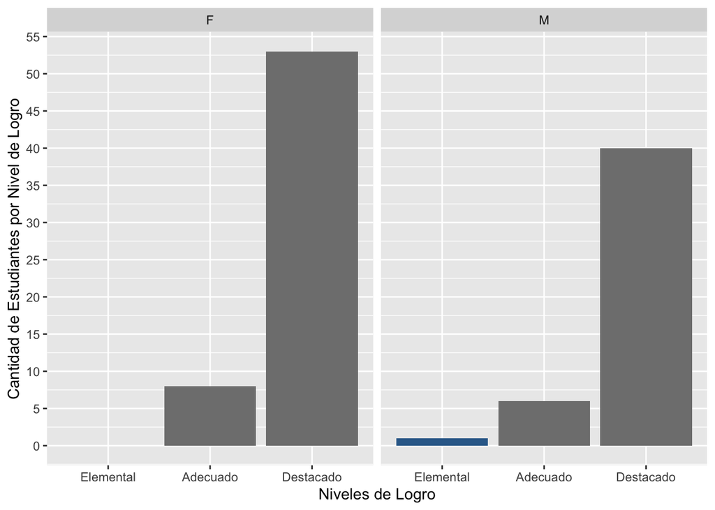

#### 0.3.3.3 Cuartos Básicos

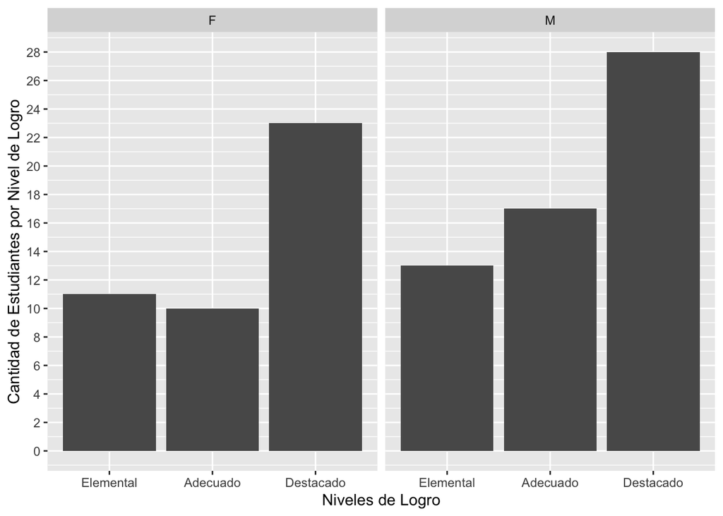

#### 0.3.3.4 Quintos Básicos

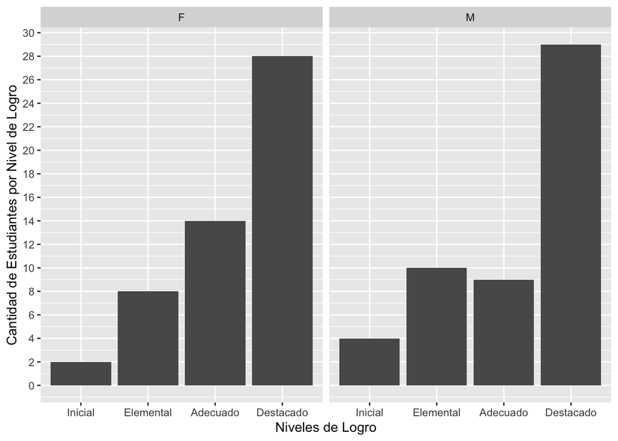

#### 0.3.3.5 Sextos Básicos

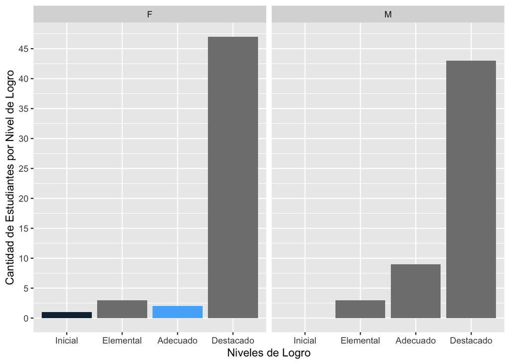

#### 0.3.3.6 Séptimos Básicos

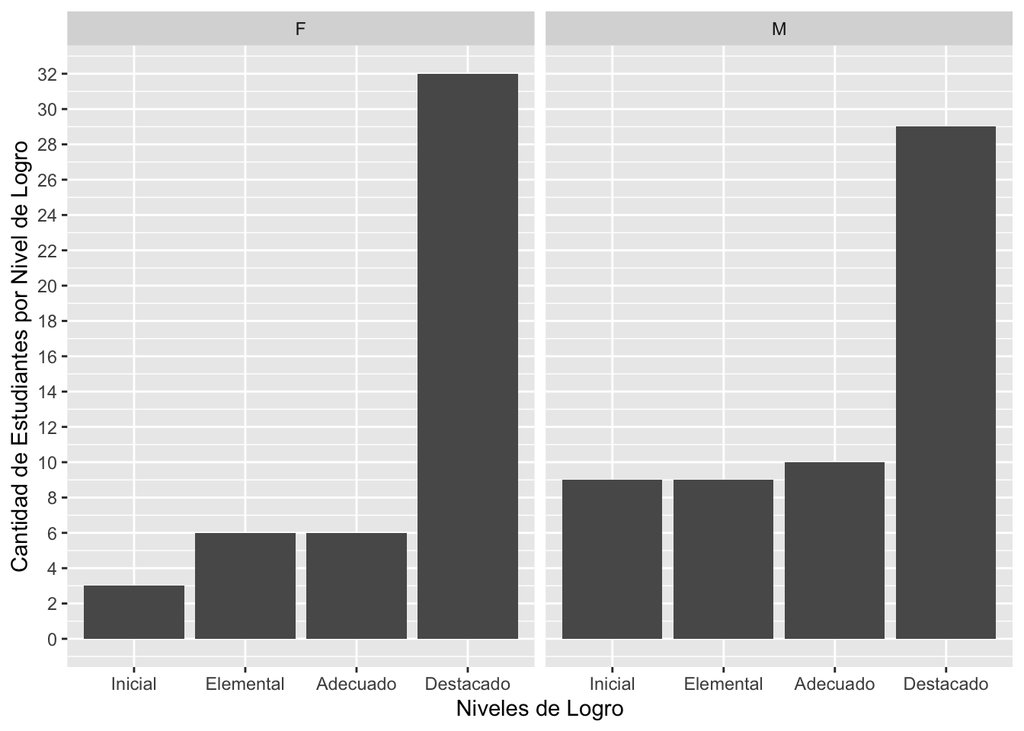

#### 0.3.3.7 Octavos Básicos

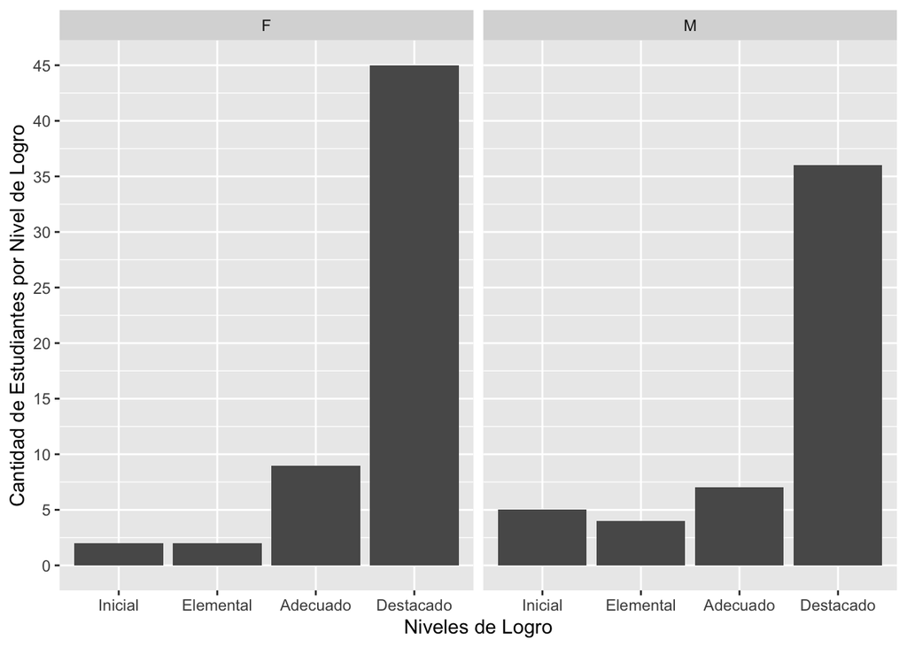

#### 0.3.3.8 Primeros Medios

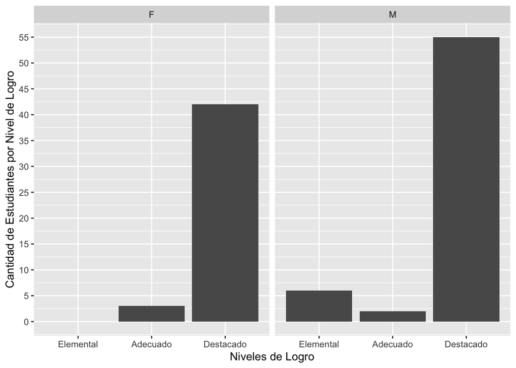

#### 0.3.3.9 Segundos Medios

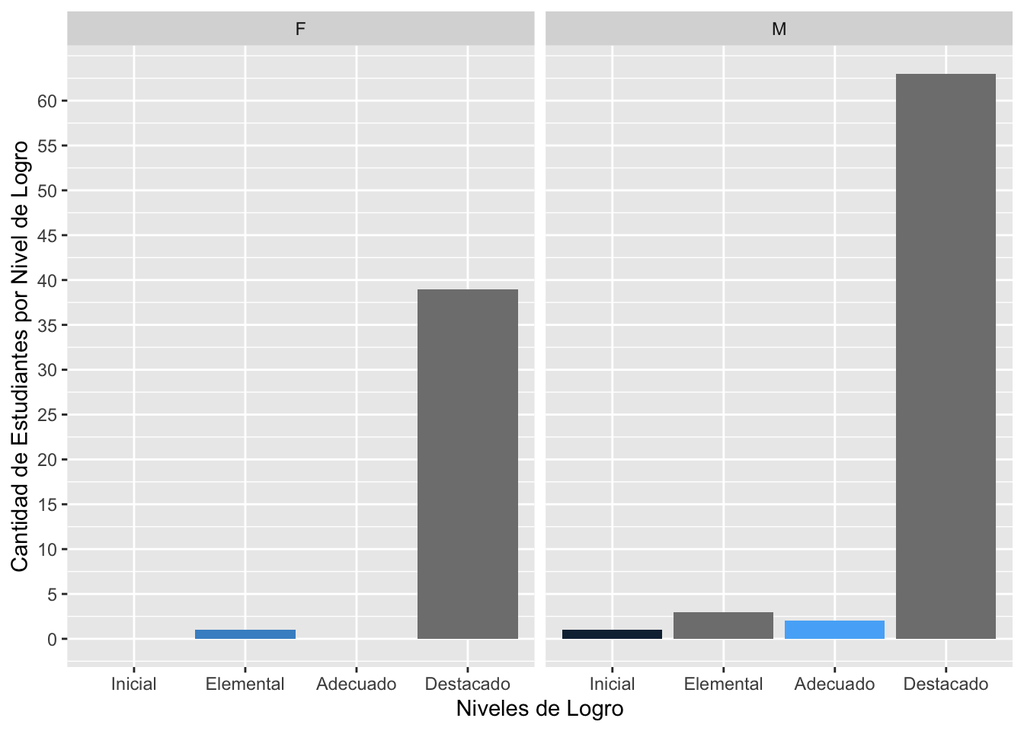

## 0.4 Metas de Aprendizajes

Se presentan las metas declaradas por el sector desde 1º básico a IIIº medio (al 15 de julio). Ajustar las metas considerando los siguientes criterios:

- **¿Contienen errores gramaticales:** **Redacción, Faltas de Ortografía** **?**
- **¿Están escritas de manera clara y precisa(son medibles)** Ejemplo: *Comprenderán que Dios elige a María para ser la Madre de Jesús y analizarán por qué es modelo de vida para los cristianos. Además, identificarán el significado del tiempo liturgico de Adviento y cómo nos prepara para vivir con ilusión la Navidad, así mismo explicarán el verdadero significado de la Navidad. (Segundo básico)* **En este caso hay tres temas en uno. Hay que revisar esto porque se repite en varias metas.**
- **¿Dan cuenta de aprendizajes relevantes que deben adquirir mis estudiantes? ¿Es coherente con el plan de estudios?** Ejemplo: *“Reconocen las variantes que ocasionan el mal en la sociedad (séptimo básico)”*. **¿Es una meta relevante o es un objetivo que debe ser parte de una meta? Además, el verbo reconocer es bastante básico en cuanto a aprendizaje para ser una meta.**
- **¿La meta da cuenta de aprendizajes o de productos a lograr?** Ejemplo: *“Crean proyecto de intervención cultural que se desprende de los conocimientos adquiridos de la Doctrina social de la Iglesia analizando las variantes de su aplicación en el siguiente año academico” (tercero medio).* **En este caso: ¿Es una meta o la evaluación de una meta? Además, no puede quedar para el próximo año, debe evaluarse ahora.**
- **Ajustar las metas que contengan verbos que son poco precisos a la hora de medir:** *Comprender, Reflexionar*. **Pero también, aquellas que contengan verbos que den cuenta de niveles básicos de aprendizaje:** *Identificar, Reconocer*. **Las metas de aprendizajes deben ser** *Medibles* **pero también** *Desafiantes*.

### 0.4.1 Metas de Aprendizajes Primer Ciclo

| Nivel | Segunda Unidad | Tercera Unidad |
| --- | --- | --- |
| Primero Básico | Identificarán que todos tenemos distintas capacidades y nos podemos complementar para hacer de este mundo un mejor lugar. | Analizarán que hay objetos y lugares sagrados que se reservan para nuestra relación con Dios y por qué los cristianos estamos invitados a celebrar el nacimiento de Jesús. |
| Segundo básico | Comprenderán que Dios se da a conocer en la Biblia, que es su Palabra y analizarán parte básica de la estructura de la Biblia. Además, comprenderán que el Antiguo Testamento nos cuenta la historia de … | Comprenderán que Dios elige a María para ser la Madre de Jesús y analizarán por qué es modelo de vida para los cristianos. Además, identificarán el significado del tiempo liturgico de Adviento y cómo … |

### 0.4.2 Metas de Aprendizajes Segundo Ciclo

| Nivel | Segunda Unidad | Tercera Unidad |
| --- | --- | --- |
| Tercero básico | Reflexionán y explicarán cómo respondemos al amor de Dios y analizarán la invitación que nos hace Jesús a perdonar a los demás. | Reflexionarán y comprenderán sobre la fuerza y el amor que Dios nos entrega mediante el Espíritu Santo y recordarán la importancia del SÍ de María para nuestra salvación.. |
| Cuarto básico | Comprender que Jesús hace presente el Reino de Dios, por medio de sus palabras y acciones, enseñando que no es un reino como los que acostumbramos conocer, sino que es un Reino en el que todos tenemos… | Comprender que el Reino de Dios se hace presente en el momento en que nos relacionamos con otros, viviendo de manera solidaria, identificando al otro como mi hermano/a. |
| 5º básico | Comprender que el llamado a ser testigo de Dios, es una invitación a anunciar su cercanía y cariño por sus hijos e hijas, reconociéndolo como un Padre amoroso que nunca nos abandona. | Comprender que Jesús es nuestro gran amigo que nos muestra el camino hacia Dios Padre, por medio de sus enseñanzas, y que María es nuestra Madre, modelo de fe y entrega. |
| 6º básico | Reflexionarán y analizarán las enseñanzas que nos dejó Jesús, para poder ponerlas en práctica hoy. | Reconocerán y argumentarán el ejemplo que nos da en su vida María como camino de santidad. |

### 0.4.3 Metas de Aprendizajes Tercer y Cuarto Ciclo (7º básico a IIIº medio)

| Nivel | Segunda Unidad | Tercera Unidad |
| --- | --- | --- |
| Séptimo básico | Reconocen las variantes que ocasionan el mal en la sociedad. | Descubrir el papel que tiene el ser humano en la creación de Dios. |
| Octavo básico | Reconocer los Sacramentos de perdón como una forma de vincularse con Dios desde lo material a lo espiritual. | Reconocer los Sacramentos de servicio como una forma de vincularse con Dios desde lo material a lo espiritual. |
| Primero medio | Identifican problemáticas que interfieren en la probreza espiritual/material. | Vinculan los 10 mandamientos y el orden moral del ser humano en búsqueda de la felicidad. |
| Segundo medio | Investigan sucesos importantes que marcan la Historia de la Iglesia dede la edad media hasta el siglo XXI. Presentan su investigación por medio de un portafolio digital en Gsuite. | Investigan sucesos importantes que marcan la Historia de la Iglesia dede la edad media hasta el siglo XXI. Presentan su investigación por medio de un portafolio digital en Gsuite. |
| Tercero medio | Conocen los pilares fundametales de la Doctrina Social de la Iglesia que se desprenden de los documentos Magisteriales. | Crean proyecto de intervención cultural que se desprende de los conocimientos adquiridos de la Doctrina social de la Iglesia analizando las variantes de su aplicación en el siguiente año academico. |

## 0.5 Plan de Evaluación II Semestre 2021

En la siguiente tabla se presentan los procedimientos e instrumentos declarados por el sector (1º básico en adelante) y la cantidad de veces que se repiten. Revisar lo declarado en el plan de evaluación considerando los siguientes criterios:

- ¿Hay claridad en el sector entre lo que es un procedimiento y su diferencia con el instrumento? **En el caso de dudas, revisar nuestro [Reglamento de Evaluación](https://www.colsanjavier.cl/files/documentos/REGLAMENTO%20INTERNO%20DE%20EVALUACIÓN%202021.%20%5Bv.%2030-04-2021%5D.pdf).**
- ¿Existe una diversidad de formas de evaluar o se limitan a la práctica recurrente de procedimientos e instrumentos utilizados en el sector? **Es necesario revisar si, en la implementación, hay diferencias metodológicas entre Pruebas/Test, Informe/Avance. Además, de especificar que significa un prototipo o si la investigación es parte de un proceso o es el único producto.**
- ¿Lo declarado, permite dar cuenta de manera adecuada de los OA y, sobre todo, de las metas definidas en el sector?

Por último, se agrega una nube de palabras que quiere reflejar el peso de los instrumentos/procedimientos declarados por el sector.

|  | word | freq |
| --- | --- | --- |
| prototipo | prototipo | 31 |
| prueba | prueba | 30 |
| investigación | investigación | 7 |
| avance | avance | 4 |
| ensayo | ensayo | 4 |
| informe | informe | 4 |
| test | test | 2 |

[interactive chart not shown]

En el caso del **Plan de Nivel**, les solicito que cómo sector concuerden y plasmen en la planificación:

- En qué sesiones se evaluará el o los OA que se hacen responsables.
- El o los instrumentos que usarán para concretar esta evaluación.

Es importante que ustedes como jefes de sector hagan sequimiento de este proceso, ya que es el medio con el cual concretamos la formación integral. Pero, además, los resultados obtenidos, es lo que informamos a los estudiantes y sus familias en los distintos objetivos de aprendizajes asociados a las tres dimensiones de nuestro Mapa de Formación Integral.